# EDA of the FIFA World Cup

Final Project  
Data Science 1 with R (STAT 301-1)

Author

Sonia Bhatia

Published

December 6, 2023

**Github Repo Link**

My github link is below.

https://github.com/stat301-1-2023-fall/final-project-1-soniab101

**Link to kaggle dataset (citation)**

[World Cups and World Cup Matches datasets](https://www.kaggle.com/datasets/abecklas/fifa-world-cup?select=WorldCups.csv)

## Introduction

These datasets about the FIFA World Cup are interesting to me since I enjoy watching soccer matches, especially the World Cup. One dataset contains overall information on the World Cup held every four years, and the other contains specific information about each match held in each World Cup. I believe there are many conclusions that can be drawn from this data, and many interesting questions that can be explored. Some questions I am interested in investigating are related to the attendance of the matches and of the overall World Cup. For instance, I want to investigate into which countries have a higher average match attendance. I am also interested in how the performances of teams have changed over time, and want to use the number of goals scored as a metric to measure this.

## Data Overview & Quality

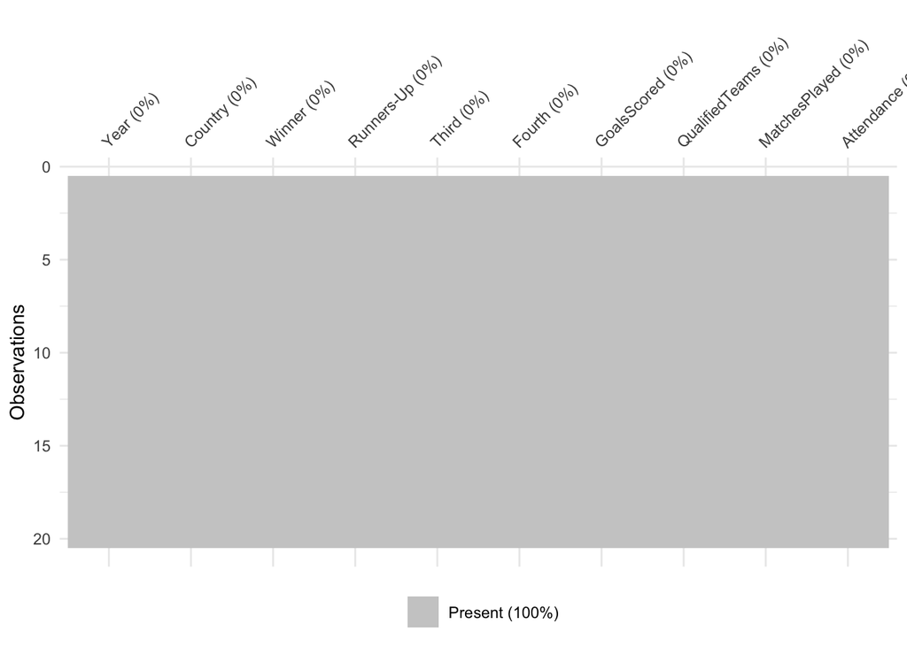

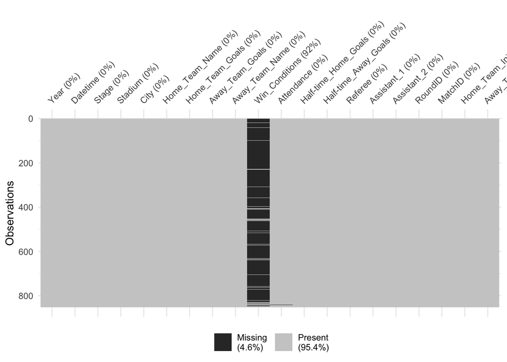

## Summary of the datasets

Summary Statistics

| Variable | N | Mean | Std. Dev. | Min | Pctl. 25 | Pctl. 75 | Max |
| --- | --- | --- | --- | --- | --- | --- | --- |
| Year | 852 | 1985 | 22 | 1930 | 1970 | 2002 | 2014 |
| Home_Team_Goals | 852 | 1.8 | 1.6 | 0 | 1 | 3 | 10 |
| Away_Team_Goals | 852 | 1 | 1.1 | 0 | 0 | 2 | 7 |
| Match_Attendance | 850 | 45165 | 23485 | 2000 | 30000 | 61374 | 173850 |
| Half-time_Home_Goals | 852 | 0.71 | 0.94 | 0 | 0 | 1 | 6 |
| Half-time_Away_Goals | 852 | 0.43 | 0.69 | 0 | 0 | 1 | 5 |
| RoundID | 852 | 10661773 | 27296132 | 201 | 262 | 249722 | 97410600 |
| MatchID | 852 | 61346868 | 111057172 | 25 | 1189 | 43950059 | 300186515 |
| GoalsScored | 852 | 131 | 30 | 70 | 102 | 147 | 171 |
| QualifiedTeams | 852 | 24 | 7.2 | 13 | 16 | 32 | 32 |
| MatchesPlayed | 852 | 49 | 15 | 17 | 35 | 64 | 64 |
| Total_Attendance_of_WC | 852 | 2285409 | 977086 | 363000 | 1563135 | 3178856 | 3587538 |

Summary Statistics

| Variable | N | Mean | Std. Dev. | Min | Pctl. 25 | Pctl. 75 | Max |
| --- | --- | --- | --- | --- | --- | --- | --- |
| Year | 20 | 1975 | 26 | 1930 | 1957 | 1995 | 2014 |
| GoalsScored | 20 | 119 | 33 | 70 | 89 | 145 | 171 |
| QualifiedTeams | 20 | 21 | 7.3 | 13 | 16 | 26 | 32 |
| MatchesPlayed | 20 | 42 | 17 | 17 | 30 | 55 | 64 |
| Attendance | 20 | 1872882 | 1071842 | 363000 | 874832 | 2725173 | 3587538 |

Summary Statistics

| Variable | N | Mean | Std. Dev. | Min | Pctl. 25 | Pctl. 75 | Max |
| --- | --- | --- | --- | --- | --- | --- | --- |
| Year | 852 | 1985 | 22 | 1930 | 1970 | 2002 | 2014 |
| Home_Team_Goals | 852 | 1.8 | 1.6 | 0 | 1 | 3 | 10 |
| Away_Team_Goals | 852 | 1 | 1.1 | 0 | 0 | 2 | 7 |
| Attendance | 850 | 45165 | 23485 | 2000 | 30000 | 61374 | 173850 |

I wanted to investigate some summary statistics of the numerical variables in each dataset. Something that stood out to me was the wide range of the total matches played in the world cup (17 - 64) which has definitely increased over time. I was also surprised at how high the mean total attendance was at the world cups.

# Joining Datasets

Firstly, I started out by joining my two datasets: World Cups and World Cup Matches. I looked for overlapping vars that I could use as a key to join my datasets, and decided to join them by Year since that is unique to each World Cup. I called this joined dataset Cups_Matches_Joined. After joining, I realized that further cleaning of the dataset was necessary.

I noticed that the team name Germany was coded both as Germany and also Germany FR. After investigating the meaning of this, I realized that Germany FR was West Germany before the country was reunified. I decided to recode Germany FR as Germany, since that is how the country is considered today, and their overall world cup wins are measured for the country as a whole officially. Additionally, I parsed the Datetime variable in the World Cup Matches dataset, and turned it into a date object. Also, I renamed many of the variable names in the dataset that contained a space in them, since this can be problematic when referring to them in plotting and later code. I renamed them to use an underscore rather than a space. I needed to recode the attendance variable in the WorldCups dataset, as it was a character variable rather than a numerical one. I also realized that both the variable for World Cup total attendance in the World Cups dataset and the variable for match attendance in the World Cup Matches dataset were both named attendance, so in the joined dataset I had to rename them to total_attendance_of_WC and match_attendance respectively.

After cleaning, I made subsets of my data as I was conducting my analysis that would help me answer my research questions. For example, in my dataset that I created called stages_attendance_df, I mutated the Stage variable so that all preliminary rounds of each World Cup, each with different names, would all be called ‘Early round’. My cleaned datasets are stored in my data sub-directory as csv files.

# Explorations

## Which team has the greatest number of World Cup titles?

First, I believed it would be best to answer an important question of which team, through 2014, has won the most World Cup titles. Figure 1 displays the distribution of World Cup wins, and provides some interesting insights. From this graph, I could conclude that Brazil is the country that has won the most World Cups this far with a total of 5 wins. Germany and Italy are tied for the second most wins with 4 each. Additionally, Argentina and Uruguay are tied at third with two wins. This helped me form some of my further questions about the data, which I investigate in the rest of this exploration.

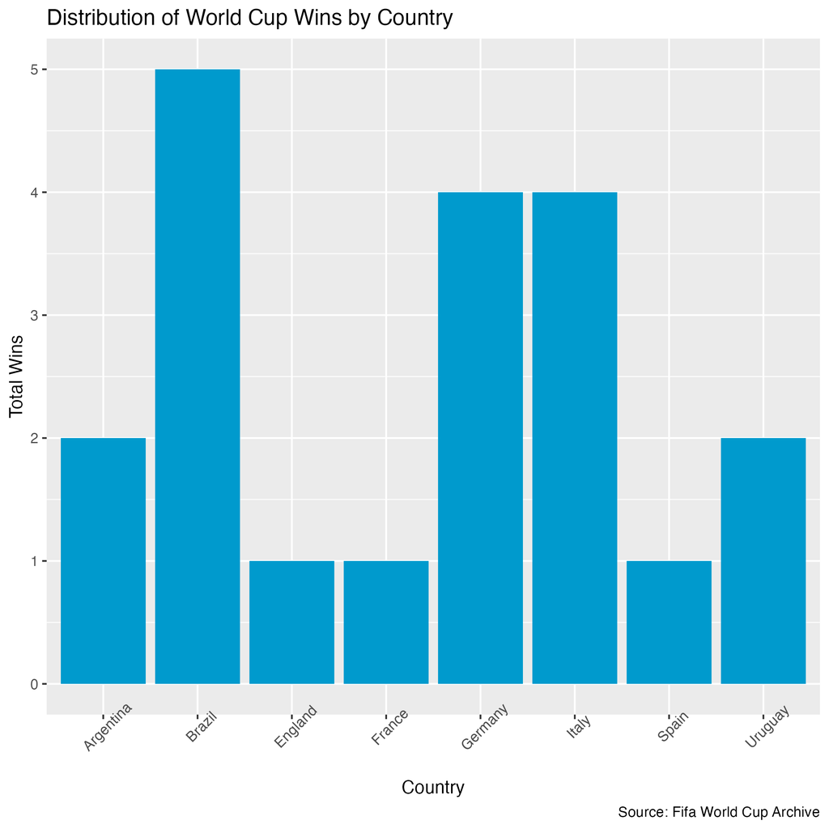

Figure 1: Distribution of World Cup Title Wins by Country

## Attendance

I wanted to investigate the both the match attendance and overall world cup attendance variables, since I feel like they may have an interesting relationship with other variables, and could even have an effect on teams’ performance during matches.

### Distribution of Match Attendance Variable

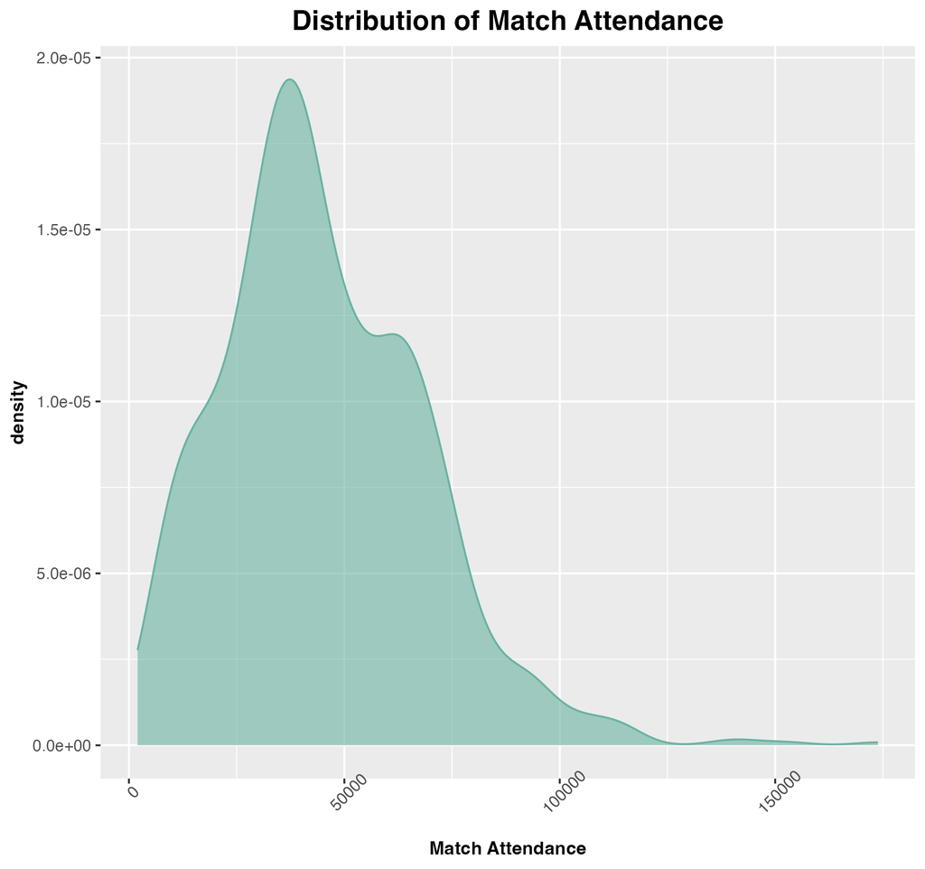

Figure 2: Distribution of Match Attendance

### Match Attendance of Certain Countries’ Teams

Next, I wanted to know how the match attendance was distributed for certain teams. I was interested to see if more people attended matches when certain countries were playing. I selected the four teams which I enjoy watching play the most, and like to keep up with the players and current team performance. I noticed that the distribution for attendance of team USA’s matches has a very tall peak to the left of the other three teams, meaning frequently around 35,000 people attended their matches which is less than the average attendances for other teams. I did not find this to be too surprising, as soccer is not as popular of a sport in the US in comparison to the other three countries. Also, other major sports in the US such as American football and baseball are rivals for the US population’s interest in sports. The distributions of the match attendance have significant overlap for the others countries, telling us that these other teams had a similar distribution of frequency.

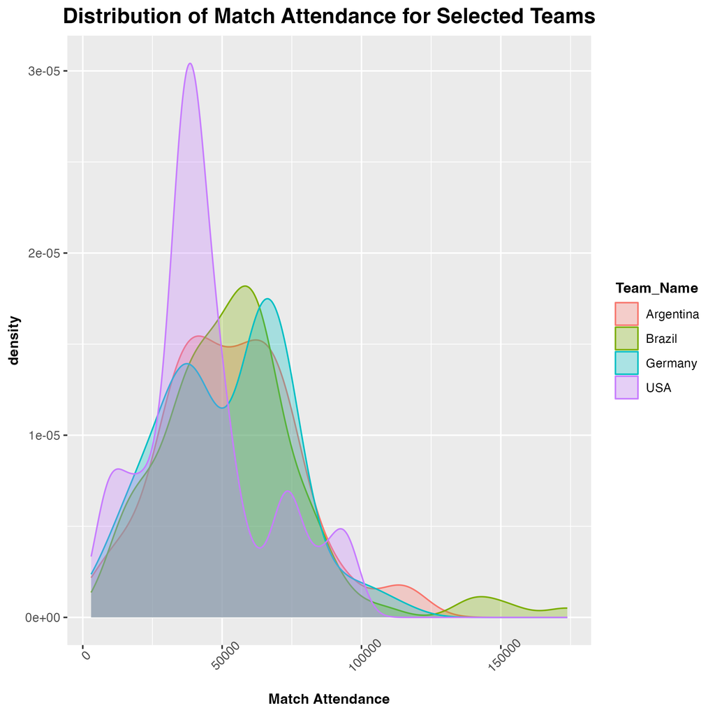

Figure 3: Distribution of Match Attendance for Selected Countries

### Match Attendance of Top Five Countries

To build on my previous analysis of match attendance for my favorite teams, I decided to investigate the match attendance of the five countries that have won the most World Cups. Figure 4 below shows us these distributions. I was surprised to see that the distributions for all five countries were pretty similar. I found it interesting that Brazil had the highest peak out of all the teams, meaning that it had the most consistent match attendance of around 55000 people. Germany has the further right peak, telling us that they have a higher and more concentrated density, so they may consistently have better attendance.

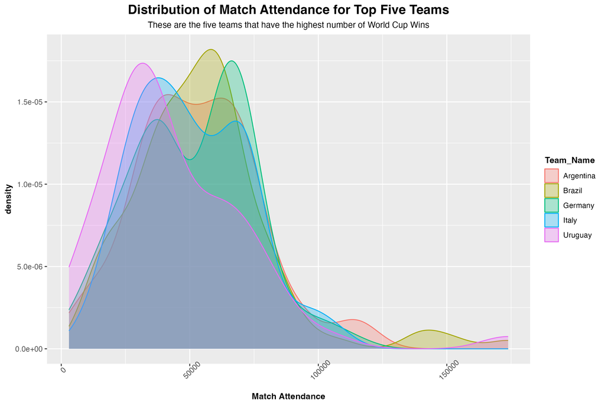

Figure 4: Distribution of Match Attendance for Top Five Teams

### Match Attendance by the Round of the World Cup

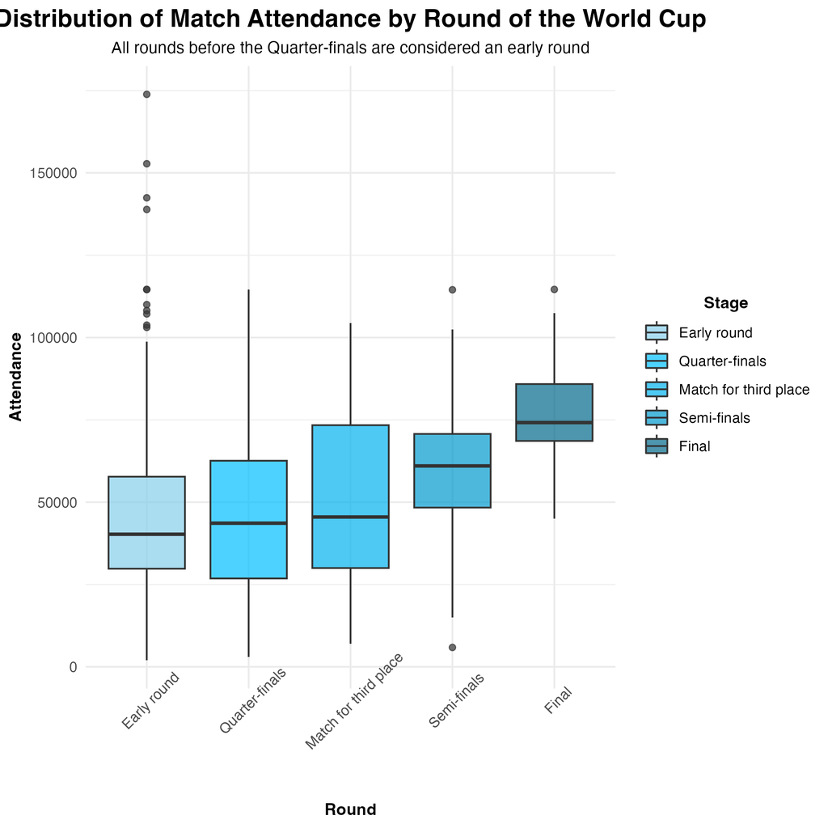

Figure 5: Match Attendance vs World Cup Round

### Total Attendance of World Cups Over the Years

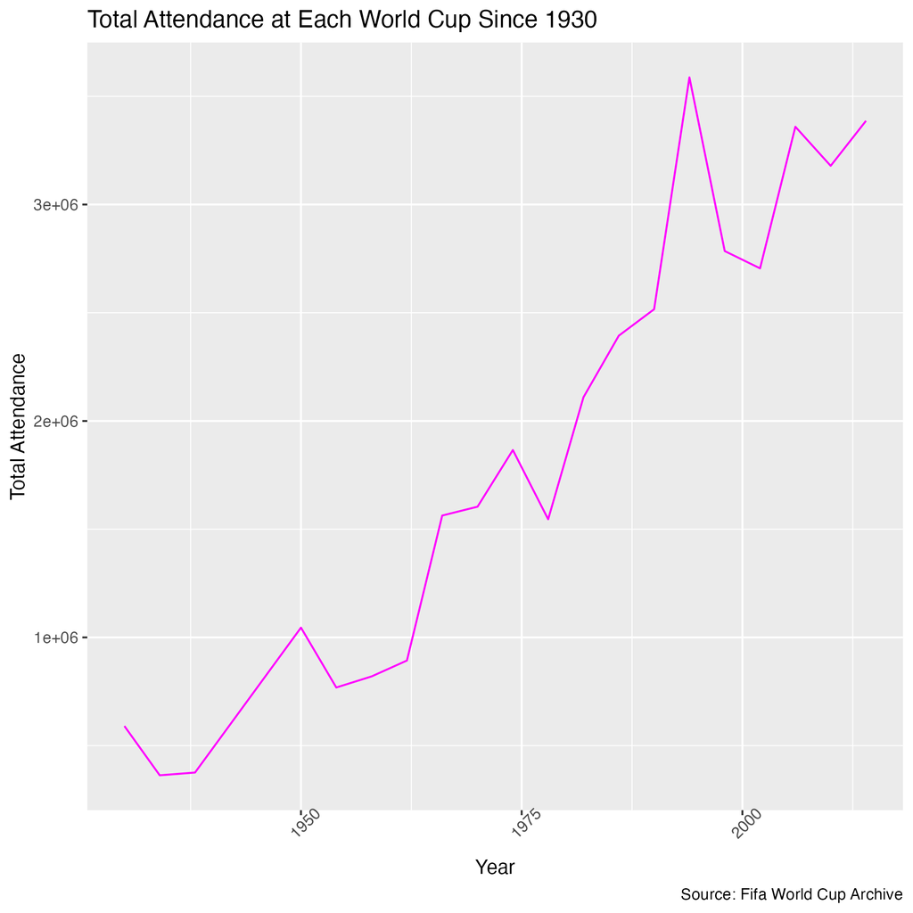

Figure 6: Total Attendance at Each World Cup

### World Cup Attendance For Each Host Country

My exploration of the trend in overall World Cup attendance motivated me to investigate how the World Cup attendance varies depending on the host country. I was especially interested in seeing which countries could have been hosting the World Cup during the years of peak attendance that we saw in Figure 6. Figure 7 below represents this investigation, by showing us the relationship between the two variables. I was surprised to see that the World Cup hosted by USA had the highest attendance out of all the World Cups thus far, especially since we learned in our earlier analysis that match attendance was lower for team USA in comparison to Argentina, Brazil, and Germany. I believe this may be due to the USA’s larger population, resulting in a larger turnout when the tournament is hosted closer. It was also interesting to see that the next 3 countries with the highest attendance are Brazil (when they hosted the second time in 2014), Germany (2006), and South Africa. I did not expect South Africa to have such a high World Cup attendance. It was interesting to see the large increase between the first and second time that certain countries hosted the World Cup.

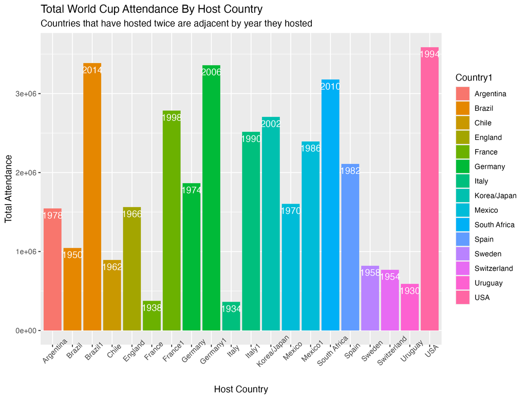

Figure 7: Overall World Cup Attendance By Host Country

## Goals Scored

Next, I wanted to investigate the variables documenting the Goals Scored, both by teams in individual matches and the total goals scored in the overall World Cup. I figured this would be a good metric to measure the performance of different teams.

### Distribution of Total Goals per World Cup

First, I looked at the distribution of the total goals scored in each World Cup to see how it varies. From figure 8 below, we can see that the data forms an interesting shape, as it is not in the shape of a bell curve, but is still symmetrical. I determined that most frequently, the total number of goals scored in a World Cup is between about 85-95 or 140-150 goals. I also found it surprising that it was equally infrequent to have the total goals be between 105-115 goals and 150-160 goals. I believe that the World Cups with a lower amount of total goals were probably earlier on when there were fewer teams that played in the tournament. Over the years, the number of teams played has increased, and maybe the skill level of the players is also greater causing the recent World Cups to have a higher total number of goals.

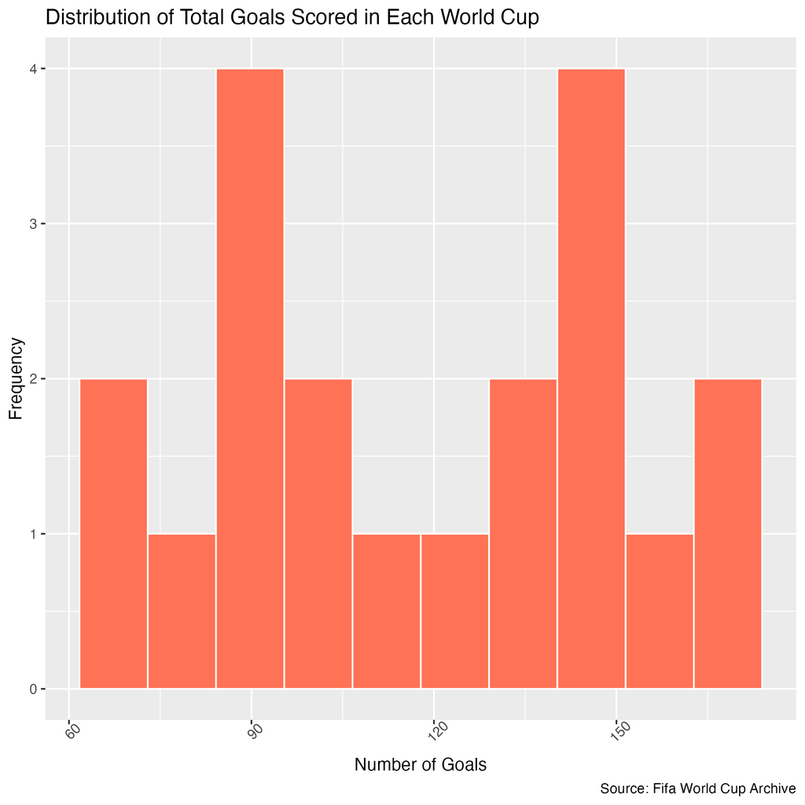

Figure 8: Distribution of Total Goals Scored per World Cup

### Total Goals Scored in the World Cup Over Time

After looking at the previous figure, I decided it would be interesting to look at how the total goals scored in each World Cup has changed over time. Figure 9 below provides some interesting insights about the trends in goals scoring. We can clearly see that over the years, the total goals scored per World Cup has greatly increased. I was surprised to see that there were steep peaks and valleys at certain years. I was especially surprised to see the steep increase of about 50 goals from the World Cup of 1950 to the World Cup of 1954, and then the sharp decrease in the following years. Maybe the World Cup of 1954 had specific high-performing teams that participated, or memorable matches that produced a unusually high number of goals.

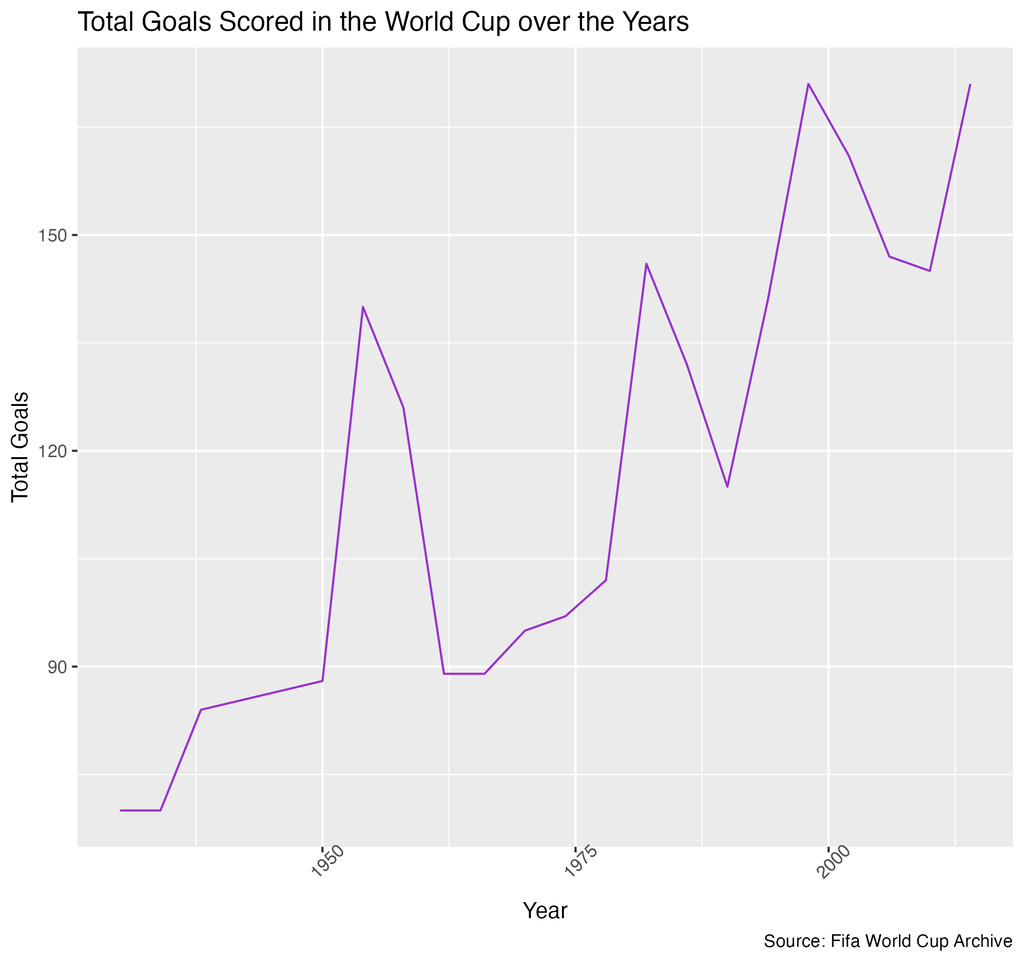

Figure 9: Total Goals Scored in the World Cup Over Time

### Total Goals of Select Teams for Recent World Cups

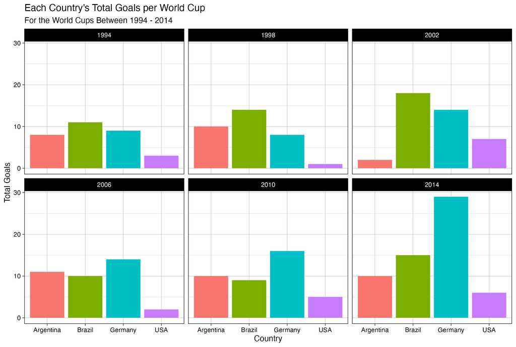

Figure 10: Teams’ Total Goals for the Recent World Cups

### Total Goals of Top Five Teams for Recent World Cups

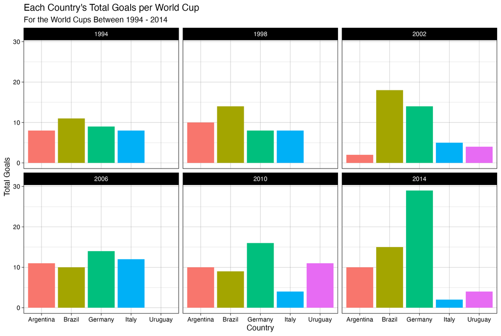

Figure 11: Top Five Teams’ Total Goals for the Recent World Cups

# Conclusion

The FIFA World Cup has greatly increased in relevance and popularity over the years, becoming a huge tournament where many teams from all over the world participate and attract millions of viewers and attendees. World Cup matches are attended by tens of thousands of people each year, with a mean attendance of about 45,000 people. I concluded that the match attendance does vary based on certain factors such as which teams are playing and what round of the World Cup we are in. For instance, team USA’s matches frequently attract a lower number of attendees (around 35,000 people) than teams like Germany and Brazil. Additionally, as I expected, my analysis supported the fact that there is a positive correlation between match attendance and the stage of the world cup we are in. The median match attendance increased as we moved from the early rounds to the quarter finals, third place, semi-finals, and the finals.

I also learned a lot about the overall total attendance of World Cups through my analysis. Looking at the trend in total World Cup attendance over the years (from 1930 - 2014), I saw that the overall attendance has increased greatly over the years from around 600,000 people in 1930 to 3,300,000 people in 2014. This is definitely attributed to more teams participating in the tournament throughout the years resulting in a large increase in the number of matches played. Additionally, the world population has greatly increased since the time of the first World Cup. Still, however this information about the trend in overall attendance demonstrates the great increase in attention and popularity the World Cup has gained over the years, and the steep peaks in attendance produce thought provoking questions regarding what could have caused the spikes in attendance. I was able to find some answers to my questions regarding how the World Cup attendance varies based on which country it is hosted in. For example, I concluded that the World Cup hosted in 1994 in USA had the highest total attendance overall, with about 3.6 million attendees. I found this surprising because I did not realize that soccer was so popular of a sport in America. Brazil and Germany had the second and third highest attendances, respectively, which was less surprising to me since these countries are well known for having very strong soccer teams.

If I were to continue exploring this dataset, I would want to continue to look at the relationships between different variables and goals scored to see how different variables relate to countries’ performances in the tournament. I would also want to investigate more into the variables of winner, runner-up, third, and fourth to see how these rankings have changed over time, or which countries consistently make the top 4 rankings. It would also be interesting to explore the geographical distribution of the winners, and even create a map highlighting how the winning countries are distributed around the world. These further explorations could provide valuable insights into how the popularity of soccer and team performance varies depending on which part of the world we look at.